# Final Project

Taketo Muroya

```r
# Setting up
library(censusapi)
library(ggplot2)
library(ggthemes)
library(lubridate)
library(tidyr)

## Census Key
Sys.setenv(CENSUS_KEY="2d27bc1c2cc9390bfa02d98962e64d2789ca30c3")
Sys.getenv("CENSUS_KEY")
```

```
## [1] "2d27bc1c2cc9390bfa02d98962e64d2789ca30c3"
```

```r
## All the census data that can be acessed with this package:
apis <- listCensusApis()
write.csv(apis, "census_variables.csv")
```

## American Community Survey (ACS)

```r
#ACS_vars <- listCensusMetadata(name="acs/acs1", vintage="2018", type="variables")
#write.csv(ACS_vars, "ACS_variables.csv")
```

### Orleans Parish, Louisiana

```r
# download the ACS data
ACS_LA <- data.frame()
for (t in 2005:2018){
ACS_LA <-
  rbind(ACS_LA,
  getCensus(name="acs/acs1", vintage=t,
            region="county:071", regionin="state:22",
            vars = c("NAME",
            "B07004H_001E", "B07004B_001E", "B07004I_001E", "C07204_001E",
            "B19101H_001E", "B19101B_001E", "B19101I_001E", "B19101_001E",
            "B25081_001E", "B25081_002E", "B25081_008E",
            "B992518_001E", "B992516_001E", "B25065_001E",  "B25062_001E",
            "B25064_001E", "B25105_001E",
            "B19037B_002E", "B19037B_019E", "B19037B_036E", "B19037B_053E",
            "B19037H_002E", "B19037H_019E", "B19037H_036E", "B19037H_053E",
            # family income for black people
            "B19101B_002E", "B19101B_003E", "B19101B_004E", "B19101B_005E",
            "B19101B_006E", "B19101B_007E", "B19101B_008E", "B19101B_009E",
            "B19101B_010E", "B19101B_011E", "B19101B_012E", "B19101B_013E",
            "B19101B_014E", "B19101B_015E", "B19101B_016E", "B19101B_017E",
            # family income for white people
            "B19101H_002E", "B19101H_003E", "B19101H_004E", "B19101H_005E",
            "B19101H_006E", "B19101H_007E", "B19101H_008E", "B19101H_009E",
            "B19101H_010E", "B19101H_011E", "B19101H_012E", "B19101H_013E",
            "B19101H_014E", "B19101H_015E", "B19101H_016E", "B19101H_017E")))
}

colnames(ACS_LA) <-
  c("state", "county", "name",
    "white", "black", "hispanic", "pop",
    "income_white", "income_black", "income_h", "income",
    "mort_t", "mort_with", "mort_out",
    "g_rent", "rent_a", "agg_g_rent", "agg_rent_a",
    "median_gross_rent", "median_housing_cost",
    "black_25", "black_25_44", "black_45_64", "black_65over",
    "white_25", "white_25_44", "white_45_64", "white_65over",
    "B01", "B02", "B03", "B04", "B05", "B06", "B07", "B08",
    "B09", "B10", "B11", "B12", "B13", "B14", "B15", "B16",
    "W01", "W02", "W03", "W04", "W05", "W06", "W07", "W08",
    "W09", "W10", "W11", "W12", "W13", "W14", "W15", "W16")

# calculate gross rent
ACS_LA$gross_rent <- ACS_LA$agg_g_rent/ACS_LA$g_rent
ACS_LA$rent_asked <- ACS_LA$agg_rent_a/ACS_LA$rent_a
ACS_LA$mortgage_rate <- 100*ACS_LA$mort_with/ACS_LA$mort_t

# income division
ACS_LA$b_income1 <- ACS_LA$B01+ACS_LA$B02+ACS_LA$B03+ACS_LA$B04
ACS_LA$b_income2 <- ACS_LA$B05+ACS_LA$B06+ACS_LA$B07+ACS_LA$B08
ACS_LA$b_income3 <- ACS_LA$B09+ACS_LA$B10+ACS_LA$B11+ACS_LA$B12
ACS_LA$b_income4 <- ACS_LA$B13+ACS_LA$B14+ACS_LA$B15+ACS_LA$B16

ACS_LA$w_income1 <- ACS_LA$W01+ACS_LA$W02+ACS_LA$W03+ACS_LA$W04
ACS_LA$w_income2 <- ACS_LA$W05+ACS_LA$W06+ACS_LA$W07+ACS_LA$W08
ACS_LA$w_income3 <- ACS_LA$W09+ACS_LA$W10+ACS_LA$W11+ACS_LA$W12
ACS_LA$w_income4 <- ACS_LA$W13+ACS_LA$W14+ACS_LA$W15+ACS_LA$W16

# setting time
ACS_LA$time <- 2005:2018

# arranging data
ACS_LA_race <-
  gather(ACS_LA, key=race, value=amount, white, black, hispanic)
ACS_LA_inc <-
  gather(ACS_LA, key=group, value=amount, income_white, income_black)
ACS_LA_black <-
  gather(ACS_LA, age, amount, black_25, black_25_44, black_45_64, black_65over)
ACS_LA_white <-
  gather(ACS_LA, age, amount, white_25, white_25_44, white_45_64, white_65over)
ACS_LA_b_inc <-
  gather(ACS_LA, income, amount, b_income1, b_income2, b_income3, b_income4)
ACS_LA_w_inc <-
  gather(ACS_LA, income, amount, w_income1, w_income2, w_income3, w_income4)
```

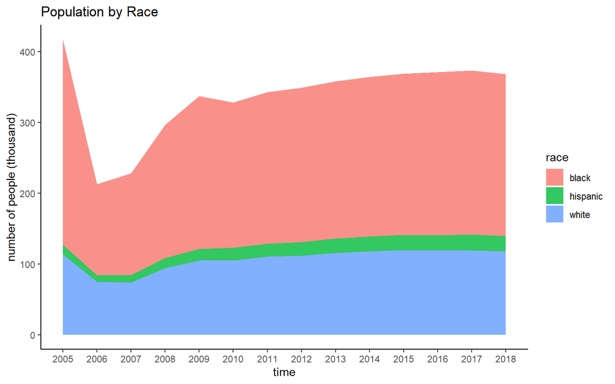

```r
ggplot(ACS_LA_race, aes(x=time, y=amount/1000, fill=race))+
  geom_area(alpha=0.8)+theme_classic()+ylab("number of people (thousand)")+
  ggtitle("Population by Race")+scale_x_continuous(breaks=seq(2005,2018,length=14))
```

New Orleans has more black people than white people. After Katrina, the number of black population decreased to almost half size and has not recoverd yet to the pre-Katrina level. On the other hand, white population has almost recovered.

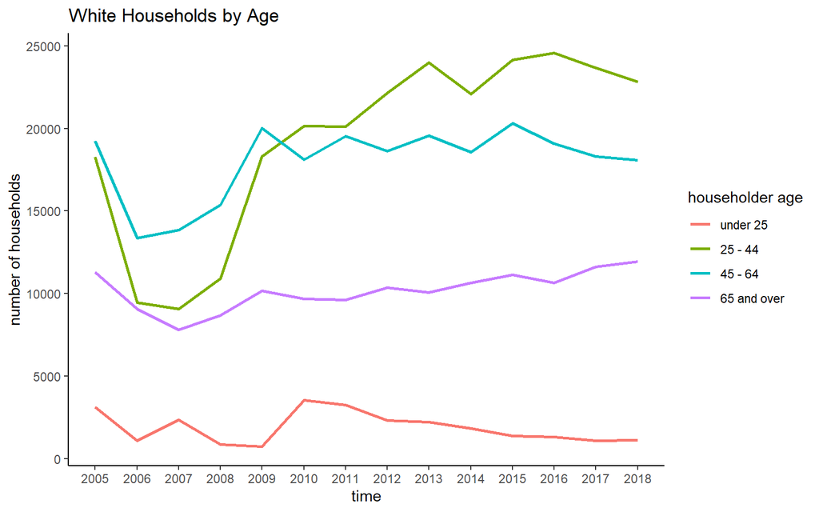

```r
ggplot(ACS_LA_white, aes(x=time, y=amount, col=age))+
  geom_line(size=1)+theme_classic()+ylab("number of households")+
  ggtitle("White Households by Age")+scale_color_discrete(name="householder age",
  labels=c("under 25", "25 - 44", "45 - 64", "65 and over"))+
  scale_x_continuous(breaks=seq(2005,2018,length=14))
```

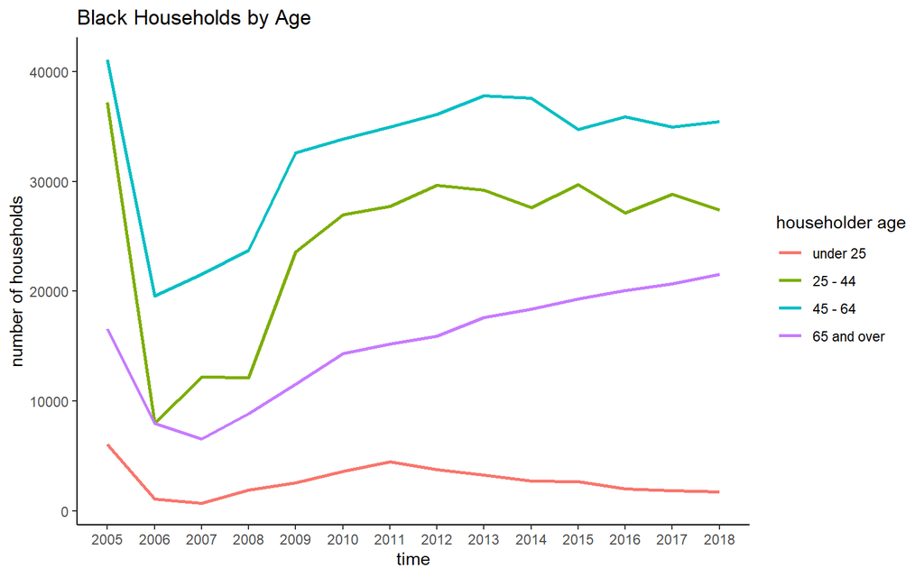

```r
ggplot(ACS_LA_black, aes(x=time, y=amount, col=age))+
  geom_line(size=1)+theme_classic()+ylab("number of households")+
  ggtitle("Black Households by Age")+scale_color_discrete(name="householder age",
  labels=c("under 25", "25 - 44", "45 - 64", "65 and over"))+
  scale_x_continuous(breaks=seq(2005,2018,length=14))
```

For black households, most of the age groups have not recovered, but the older (65+ years old) household has increased after Katrina.

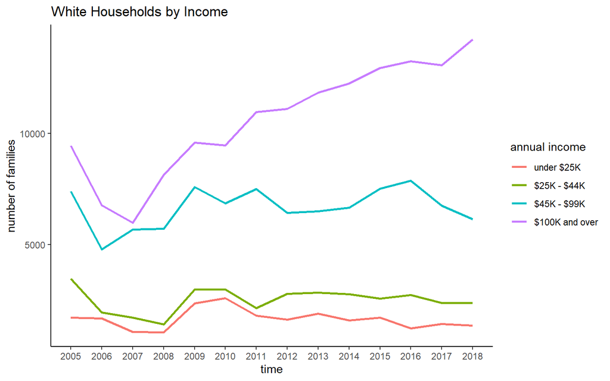

```r
ggplot(ACS_LA_w_inc, aes(x=time, y=amount, col=income))+
  geom_line(size=1)+theme_classic()+ylab("number of families")+
  ggtitle("White Households by Income")+scale_color_discrete(name="annual income",
  labels=c("under $25K", "$25K - $44K", "$45K - $99K", "$100K and over"))+
  scale_x_continuous(breaks=seq(2005,2018,length=14))
```

The rich white households have increased after Katrina.

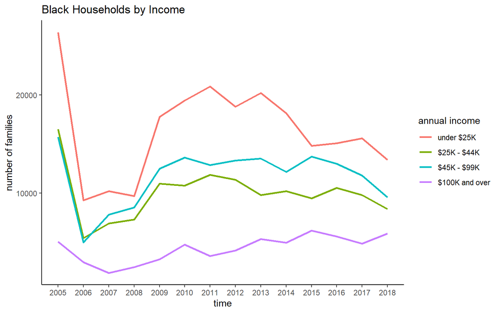

```r
ggplot(ACS_LA_b_inc, aes(x=time, y=amount, col=income))+
  geom_line(size=1)+theme_classic()+ylab("number of families")+
  ggtitle("Black Households by Income")+scale_color_discrete(name="annual income",
  labels=c("under $25K", "$25K - $44K", "$45K - $99K", "$100K and over"))+
  scale_x_continuous(breaks=seq(2005,2018,length=14))
```

The low and middle income households of black people have not recovered yet to the pre-Katrina level. Therefore, while relatively younger and richer white people come in New Orleans, relatively poorer black people might be pushed out and older households remain after Katrina.

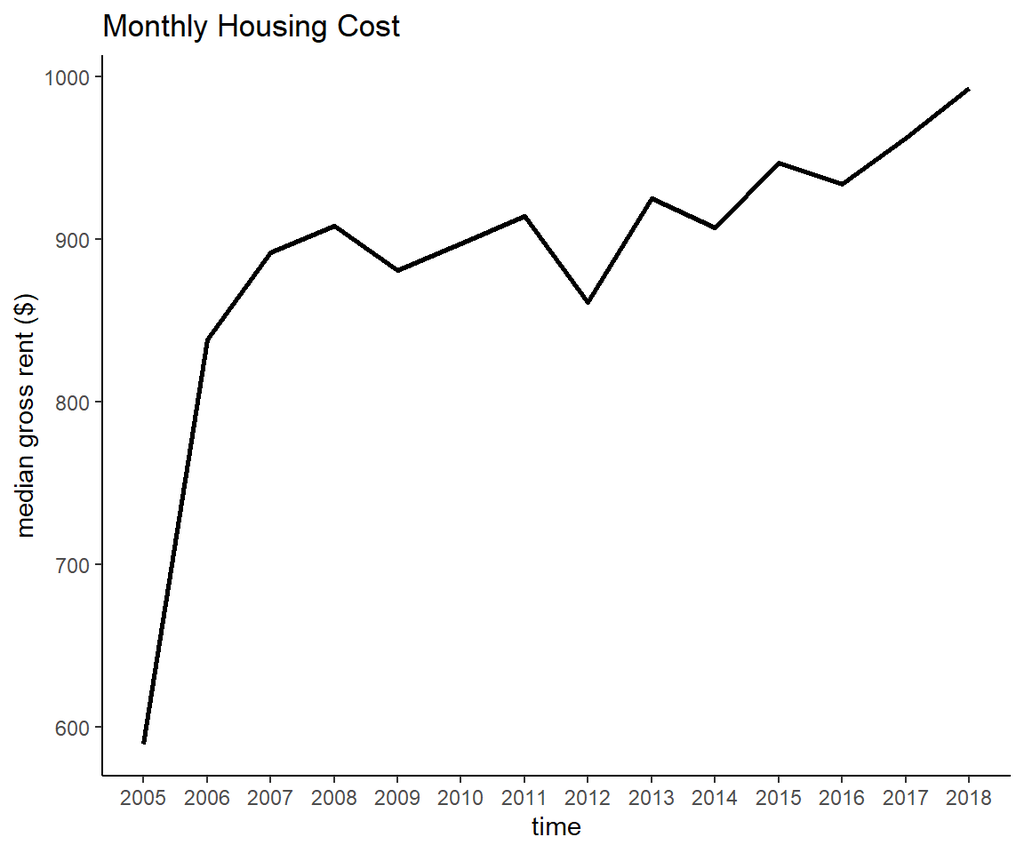

```r
ggplot(ACS_LA, aes(x=time, y=median_gross_rent))+geom_line(size=1)+
  theme_classic()+ylab("median gross rent ($)")+ggtitle("Monthly Housing Cost")+
  scale_x_continuous(breaks=seq(2005,2018,length=14))
```

The housing cost (rent fee) has increased after Katrina.

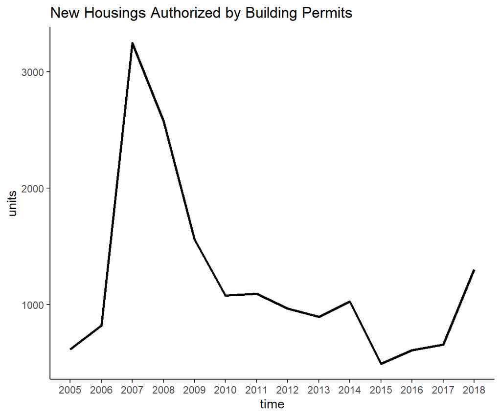

```r
housing <- read.csv("new_housing.csv")

ggplot(housing, aes(x=time, y=housing))+geom_line(size=1)+theme_classic()+
  ylab("units")+ggtitle("New Housings Authorized by Building Permits")+
  scale_x_continuous(breaks=seq(2005,2018,length=14))
```